# *Estimating $\pi$ Using The Monte Carlo Method*

[figure not shown]

### Author: Spencer Long

> **This lesson was designed for and presented at PyHawaii's $\pi$ night.**

**Goal:** Estimate $\pi$ using the Monte Carlo method.

**Cool Sources:**

Kaimi's Method For Estimating $\pi$: https://github.com/kaimibk/Pi_Day/blob/master/Monte_Carlo_Pi.ipynb

How to Integrate Using Monte Carlo: https://www.youtube.com/watch?v=WAf0rqwAvgg

Monte Carlo Method WIKI: https://en.wikipedia.org/wiki/Monte_Carlo_method

# **What is Monte Carlo?**

Stanislaw Ulam

> Monte Carlo method is a mathematical technique that generates random variables for modelling risk or uncertainty of a certain system.

> The method is used extensively in a wide variety of fields such as physical science, computational biology, statistics, artificial intelligence, and quantitative finance. (The Economic Times)

For the problem we will tackle today we will be drawing random samples from a probability distribution and accepting or rejecting the samples based on some criteria we define.

# **How to Pull $\pi$ Out of a Square and a Circle:**

# **What is The Area of a Square and a Circle?**

[figure not shown]

# Area of Square ($A_s$) $= length \cdot width = 2r\cdot 2r = 4r^{2}$

# Area of Circle ($A_c$) $= \pi r^{2} $

# **Finding a Relation Between The Two Objects Using a Ratio...**

# $$\frac{A_c}{A_s} = \frac{\pi r^2}{2r \cdot 2r} = \frac{\pi r^2}{4r^2} = \frac{\pi}{4}$$

# $$(4) \cdot \frac{A_c}{A_s} = \frac{\pi}{4} \cdot (4) $$

# $$\pi = 4\frac{A_c}{A_s}$$

# **Now Lets Code This in Python**

## The Set Up:

### We need a coordinate system and a example to make this easy to understand...

[figure not shown]

### How Do We Determine What Rocks Are Inside The Circle?

### The Distance Formula!

[figure not shown]

### Dependencies:

```python
# Dependencies
import numpy as np
from numpy import random
import matplotlib.pyplot as plt
import matplotlib.patches as patches
```

### Keeping Track of Our Numbers:

```python
# Number of rocks thrown
number_of_rocks = 30

# Coordinates that are within circle
x_coordinates_in_cirlce = []
y_coordinates_in_circle = []

# Coordinates that are within square
x_coordinates_in_squarish = []
y_coordinates_in_squarish = []
```

### A While Loop to Simulate The Rocks:

We have to use a uniform distribution for our random numbers as every value is equaly likely to occur in a uniform distribution such as you would think of flipping a coin or rolling a dice.

[figure not shown]

```python
count = 1

while count <= number_of_rocks:
    x = random.uniform(-1,1)
    y = random.uniform(-1,1)

    if (x**2 + y**2 <= 1):
        x_coordinates_in_cirlce.append(x)
        y_coordinates_in_circle.append(y)

    else:
        x_coordinates_in_squarish.append(x)
        y_coordinates_in_squarish.append(y)

    count += 1

pi = 4 * len(x_coordinates_in_cirlce)/number_of_rocks

print(pi)
```

```
2.933333333333333
```

```python
len(x_coordinates_in_cirlce)
```

```
22
```

### Plot It!

Note: The black dots will be the rocks that land outside the circle while the white dots are will be the rocks that landed inside the circle.

```
(-1, 1)
```

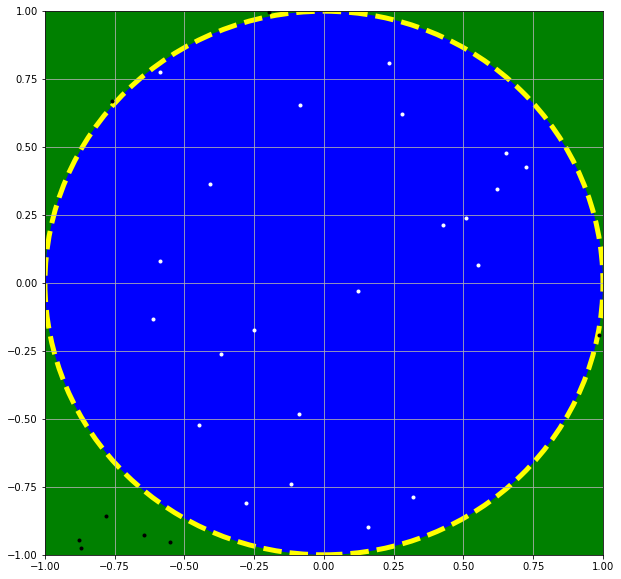

```python
circle = plt.Circle((0, 0), radius = 1, edgecolor = 'yellow',facecolor = 'b', fill = True, lw = 5, ls = '--', alpha = 1)

plt.figure(figsize = (10,10))
ax = plt.gca()

ax1 = plt.plot(x_coordinates_in_cirlce,y_coordinates_in_circle, 'w.')
ax2 = plt.plot(x_coordinates_in_squarish,y_coordinates_in_squarish, 'k.')
ax.add_artist(circle)
ax.add_patch(patches.Rectangle((-1, -1), 2, 2, color = 'green'))
ax.grid()

plt.xlim(-1,1)
plt.ylim(-1,1)
```

### Put it all into a function:

```python
def monte_carlo_pi(number_of_rocks):

    # Coordinates that are within circle
    x_coordinates_in_cirlce = []
    y_coordinates_in_circle = []

    # Coordinates that are within square
    x_coordinates_in_squarish = []
    y_coordinates_in_squarish = []

    count = 1

    while count < number_of_rocks:
        x = random.uniform(-1,1)
        y = random.uniform(-1,1)

        if (x**2 + y**2 <= 1):
            x_coordinates_in_cirlce.append(x)
            y_coordinates_in_circle.append(y)

        else:
            x_coordinates_in_squarish.append(x)
            y_coordinates_in_squarish.append(y)

        count += 1

    pi = 4 * len(x_coordinates_in_cirlce)/number_of_rocks

    circle = plt.Circle((0, 0), radius = 1, edgecolor = 'yellow',facecolor = 'b', fill = True, lw = 5, ls = '--', alpha = 1)

    plt.figure(figsize = (10,10))
    ax = plt.gca()

    ax1 = plt.plot(x_coordinates_in_cirlce,y_coordinates_in_circle, 'w.')
    ax2 = plt.plot(x_coordinates_in_squarish,y_coordinates_in_squarish, 'k.')
    ax.add_artist(circle)
    ax.add_patch(patches.Rectangle((-1, -1), 2, 2, color = 'green'))
    ax.grid()
    plt.xlim(-1,1)
    plt.ylim(-1,1)

    return print('The estimated value of Pi is:',pi)
```

### Pick a number between 100 and 1,000,000:

```
The estimated value of Pi is: 2.988
```

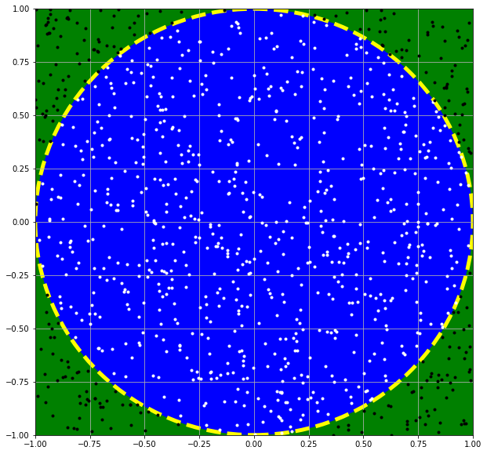

```python
monte_carlo_pi(1000)
```